# CeTF application for TCGA-STAD RNA-seq data

Carlos Biagi Jr

24/01/2020

## Loading R Packages

The first step is to load the necessary packages:

```r
library(CeTF)
library(TCGAbiolinks)
library(clusterProfiler)
```

## Loading count data

Then we will load the count table for the Stomach adenocarcinoma (TCGA-STAD) data. This data has 35 normal tissue samples (NT) and 415 primary tumor samples (TP).

```r
load("C:/Users/carlo/Desktop/TCGA/TCGA-STAD_Counts_hg19.rda")

counts <- round(exp.matrix)

samplesNT <- TCGAquery_SampleTypes(colnames(counts), "NT")
samplesTP <- TCGAquery_SampleTypes(colnames(counts), "TP")

counts <- counts[, c(samplesNT, samplesTP)]
```

## Loading TFs

The list of TFs for *Homo sapies* is provided in CeTF package. Here, we will convert from ENSEMBL to SYMBOL nomenclature.

```r
data(TFs)
convert <- bitr(TFs, fromType = "ENSEMBL",
                toType = "SYMBOL",
                OrgDb = org.Hs.eg.db::org.Hs.eg.db)
```

## Performing runAnalysis function

Finally, will be performed the complete analysis for this data

```r
out <- runAnalysis(mat = counts,
                   conditions=c("NT", "TP"),
                   lfc = 2.57,
                   padj = 0.05,
                   TFs = convert$SYMBOL,
                   nSamples1 = length(samplesNT),
                   nSamples2= length(samplesTP),
                   tolType = "mean",
                   diffMethod = "Reverter",
                   data.type = "counts")
```

```
## ##### STEP 1: Data adjustment #####
```

```
## ## 'sum' Column ##
## N     =  19938
## Mean =
##                                                                     393.2067
## Std
##                                                                          =  121.7760
## Min
##                                                                        =  0.0000
## Max =
##                                                                         450.0000
## ###########
##         #####################
```

```
## ## 'mean' Column ##
## N     =  19938
## Mean =
##                                                                     50.4315
## Std =
##                                                                          157.9228
## Min =
##                                                                        0.0000
## Max =
##                                                                         7938.0550
## ###########
##         #####################
```

```
## ###
## Correlation  =  0.1424820
## Regression   =  0.1847751
## ###
```

```
## ##### STEP 2: Differential Expression #####
```

```
## ##### STEP 3: Regulatory Impact Factors analysis #####
```

```
## ## Starting Regulatory Impact Factors analysis ##
```

```
## ##### STEP 4: Partial Correlation and Information Theory analysis #####
```

```
## ######################################
## Number of genes                 =  302
## Number of samples in condition  =  35
## ######################################
```

```
## Trios for gene    10
```

```
## Trios for gene    20
```

```
## Trios for gene    30
```

```
## Trios for gene    40
```

```
## Trios for gene    50
```

```
## Trios for gene    60
```

```
## Trios for gene    70
```

```
## Trios for gene    80
```

```
## Trios for gene    90
```

```
## Trios for gene    100
```

```
## Trios for gene    110
```

```
## Trios for gene    120
```

```
## Trios for gene    130
```

```
## Trios for gene    140
```

```
## Trios for gene    150
```

```
## Trios for gene    160
```

```
## Trios for gene    170
```

```
## Trios for gene    180
```

```
## Trios for gene    190
```

```
## Trios for gene    200
```

```
## Trios for gene    210
```

```
## Trios for gene    220
```

```
## Trios for gene    230
```

```
## Trios for gene    240
```

```
## Trios for gene    250
```

```
## Trios for gene    260
```

```
## Trios for gene    270
```

```
## Trios for gene    280
```

```
## Trios for gene    290
```

```
## Trios for gene    300
```

```
## ######################################
## Number of genes                 =  302
## Number of samples in condition  =  415
## ######################################
```

```
## Trios for gene    10
```

```
## Trios for gene    20
```

```
## Trios for gene    30
```

```
## Trios for gene    40
```

```
## Trios for gene    50
```

```
## Trios for gene    60
```

```
## Trios for gene    70
```

```
## Trios for gene    80
```

```
## Trios for gene    90
```

```
## Trios for gene    100
```

```
## Trios for gene    110
```

```
## Trios for gene    120
```

```
## Trios for gene    130
```

```
## Trios for gene    140
```

```
## Trios for gene    150
```

```
## Trios for gene    160
```

```
## Trios for gene    170
```

```
## Trios for gene    180
```

```
## Trios for gene    190
```

```
## Trios for gene    200
```

```
## Trios for gene    210
```

```
## Trios for gene    220
```

```
## Trios for gene    230
```

```
## Trios for gene    240
```

```
## Trios for gene    250
```

```
## Trios for gene    260
```

```
## Trios for gene    270
```

```
## Trios for gene    280
```

```
## Trios for gene    290
```

```
## Trios for gene    300
```

## Checking the data distribution

Before proceeding to view the results, we will check the data distribution:

#### Histogram of connectivity distribution

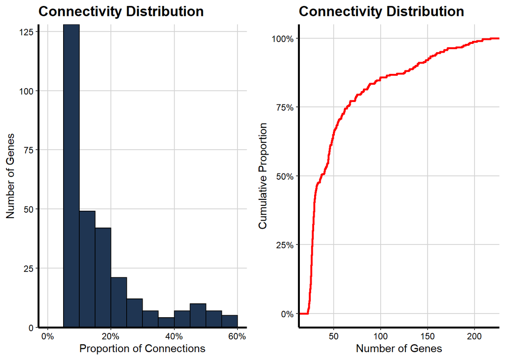

```r
# For NT condition
histPlot(OutputData(out, "pcit1", "adj_sig"))
```

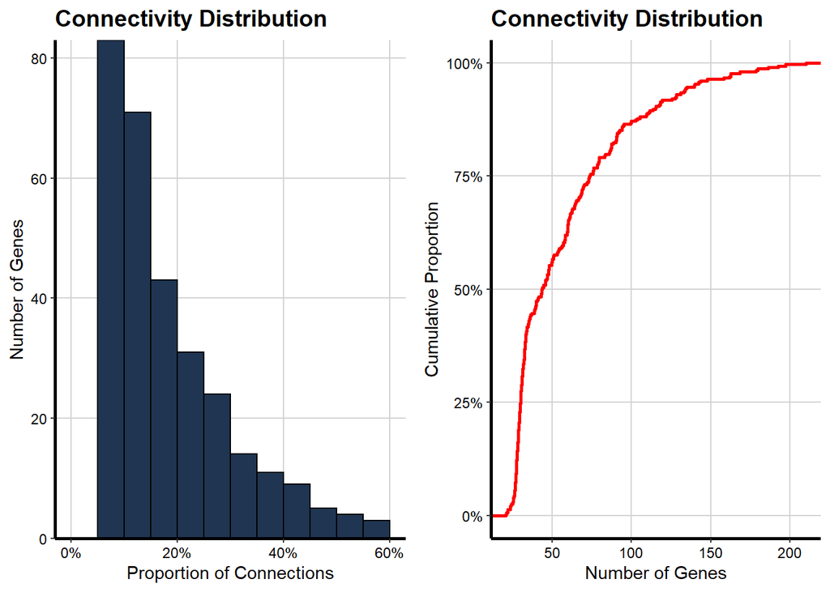

```r
# For TP condition
histPlot(OutputData(out, "pcit2", "adj_sig"))
```

#### Density distribution of correlation coefficients and significant PCIT values

It will be generated a density plot for adjacency matrices using the raw adjacency matrix and significant adjacency matrix resulted from PCIT function for both conditions (NT and TP).

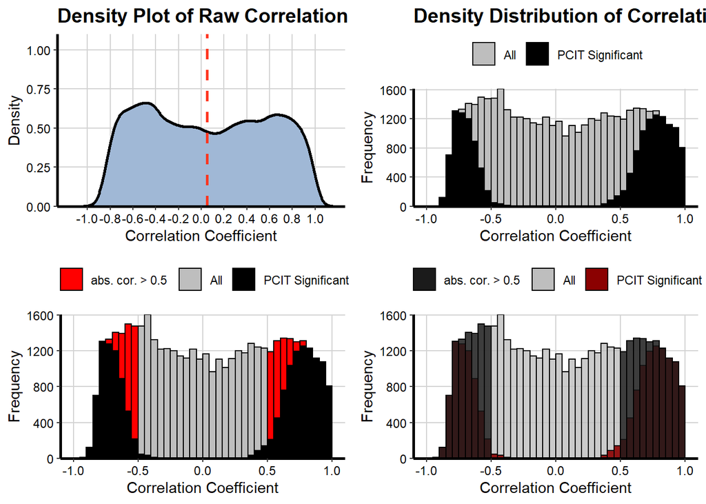

```r
# For NT condition
densityPlot(mat1 = OutputData(out, "pcit1", "adj_raw"),
            mat2 = OutputData(out, "pcit1", "adj_sig"),
            threshold = 0.5)
```

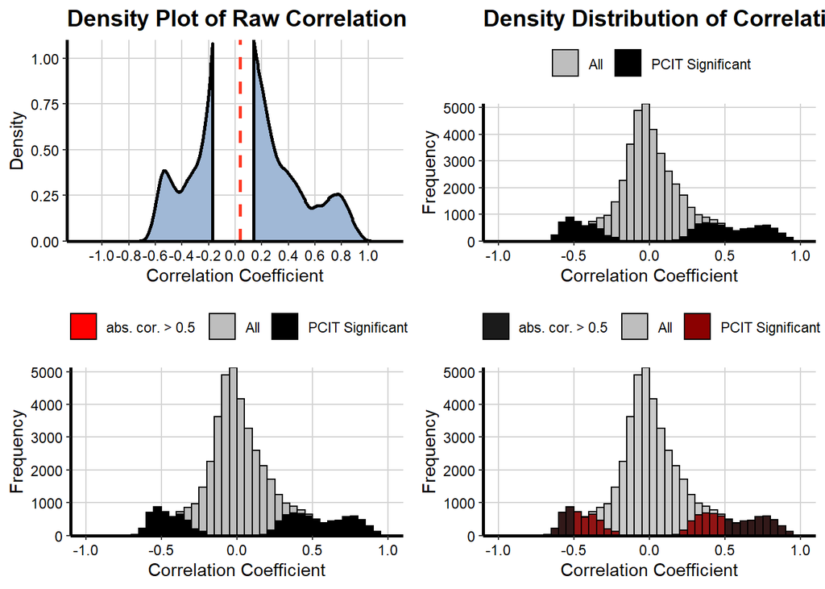

```r
# For TP condition
densityPlot(mat1 = OutputData(out, "pcit2", "adj_raw"),
            mat2 = OutputData(out, "pcit2", "adj_sig"),
            threshold = 0.5)
```

#### Relationship plots between RIF1, RIF2 and DE genes

It will be generated plots for the relationship between the RIF output analysis (RIF1 and RIF2) and for differentially expressed genes (DE).

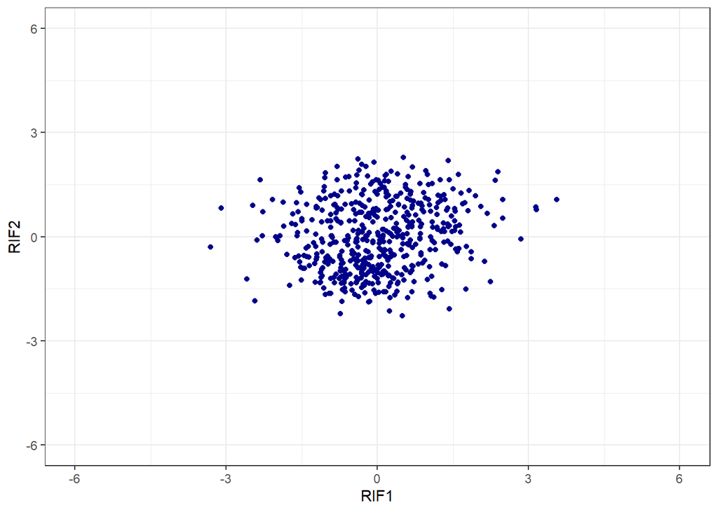

```r
RIFPlot(object = out,
        type   = "RIF")
```

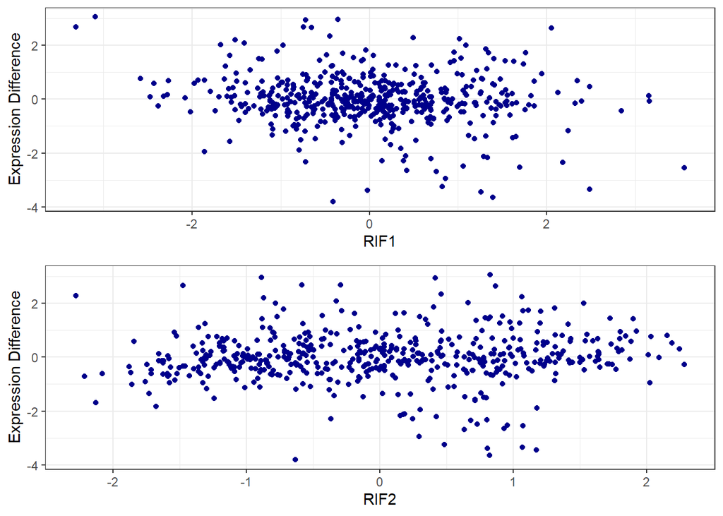

```r
RIFPlot(object = out,
        type   = "DE")
```

## Smear Plot

After checking data distribution, is possible to visualize specific results. The first one is the smear plot, that corresponds to a plot for Differentially Expressed (DE) genes and for specific TF that shows the relationship between log(baseMean) and Difference of Expression or log2FoldChange.

#### Differentially Expressed Genes (DEGs)

The first option allows the visualization of all DEGs in both conditions.

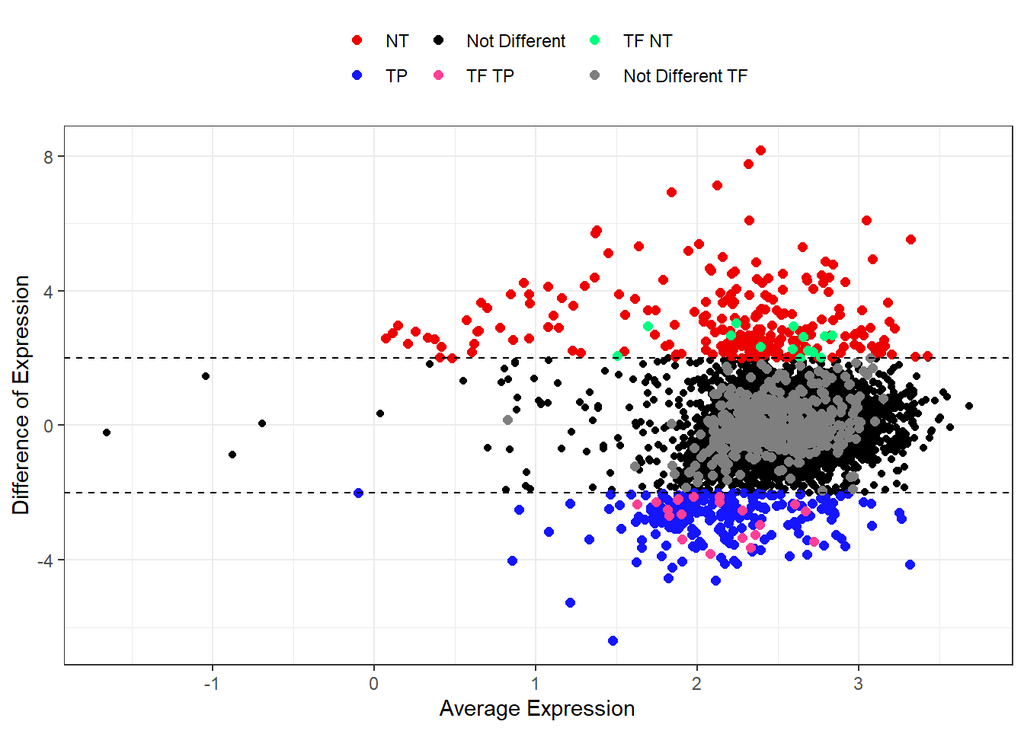

```r
SmearPlot(object = out,
          diffMethod = 'Reverter',
          lfc = 2,
          conditions = c('NT', 'TP'),
          type = "DE")
```

#### Specific TFs

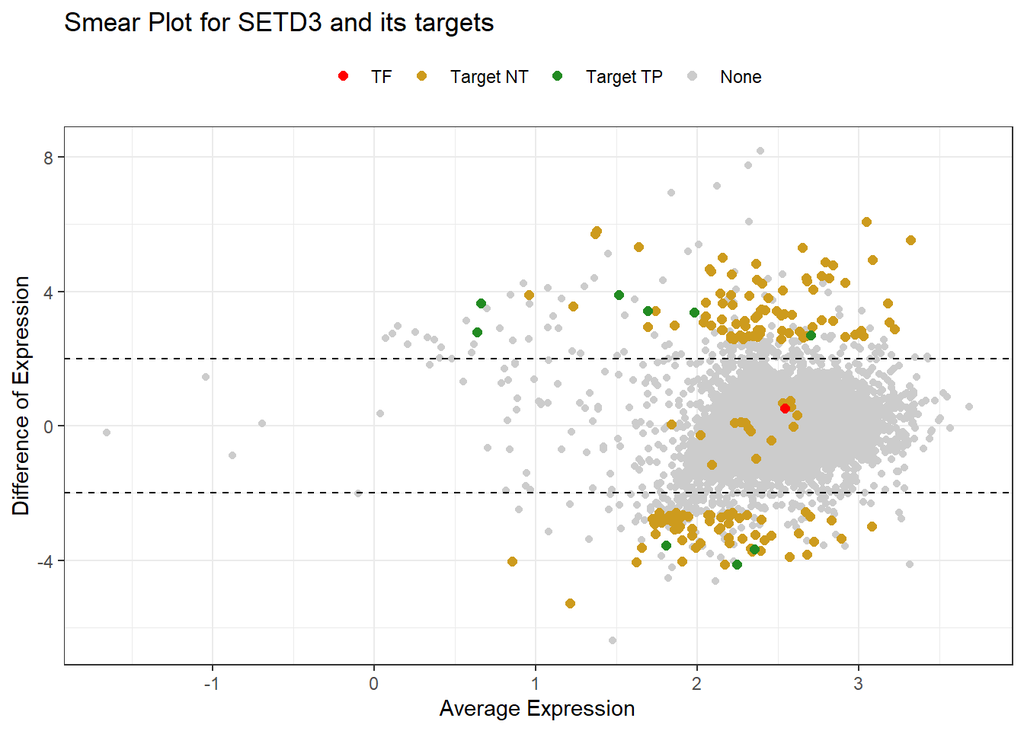

```r
SmearPlot(object = out,
          diffMethod = 'Reverter',
          lfc = 2,
          conditions = c('NT', 'TP'),
          TF = 'SETD3',
          label = FALSE,
          type = "TF")
```

## Network visualization

The package also allows visualization of the interaction networks for both conditions. Remembering that there is the possibility to access the tables of both networks using **NetworkData(out, “network1”) or NetworkData(out, “network2”)** and use Cytoscape to personalize the view of the networks.

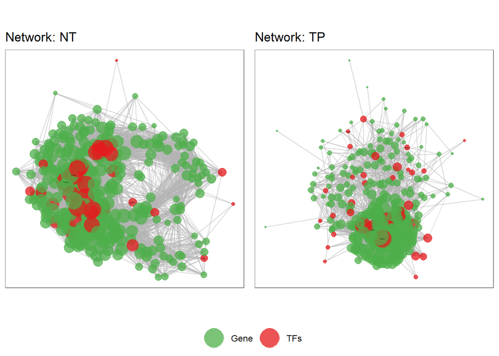

```r
netConditionsPlot(out)
```

## Network genes enrichment

After obtaining the interaction networks, it is possible to perform the functional enrichment of these genes for both conditions. In this example, we will perform enrichment only for the NT condition genes. Remembering that there is the possibility of performing a grouping of genes, better known as group GO, where only the genes that form part of the pathways will be counted, with no statistical inference. The **getGroupGO** function is used for this:

```r
# Loading Homo sapiens annotation package
library(org.Hs.eg.db)
# Selecting genes only for the NT condition
genes <- unique(c(as.character(NetworkData(out, "network1")[, "gene1"]),
                  as.character(NetworkData(out, "network1")[, "gene2"])))

enrich <- getEnrich(organism='hsapiens', database='geneontology_Biological_Process',
                    genes=genes, GeneType='genesymbol',
                    refGene=refGenes$Homo_sapiens$SYMBOL,
                    fdrMethod = 'BH', fdrThr = 0.05, minNum = 5, maxNum = 500)
```

```
## Loading the functional categories...
## Loading the ID list...
## Loading the reference list...
## Performing the enrichment analysis...
```

## Visualization of functional enrichment

This package provides four different types of visualization for functional enrichment results:

#### Heatmap-like functional classification

Enables the visualization of the enrichment analysis results from getEnrich function. The plot contains the heatmap with the associated pathways genes, the significance of the enrichment and a barplot with the enrichment ratio.

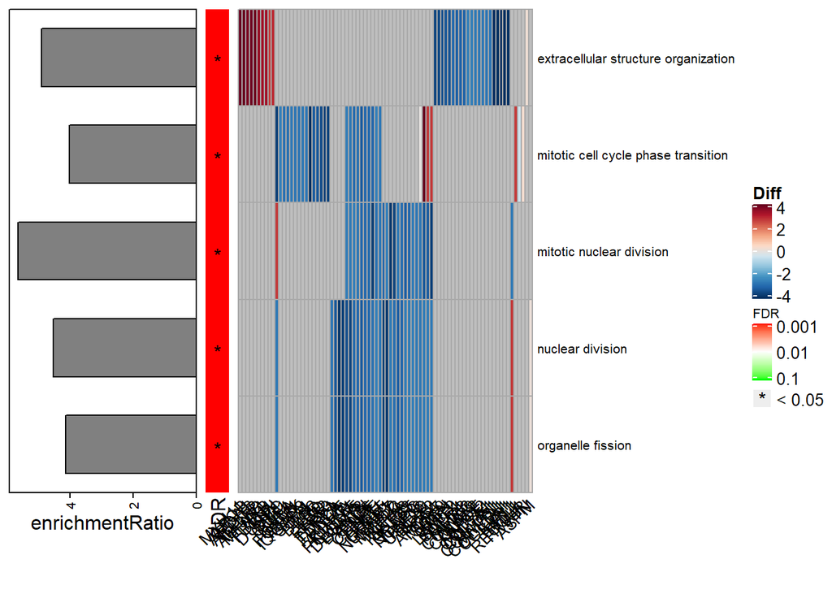

```r
heatPlot(res = enrich$results,
         diff = getDE(out, "all"),
         showCategory = 5)
```

#### Circular barplot

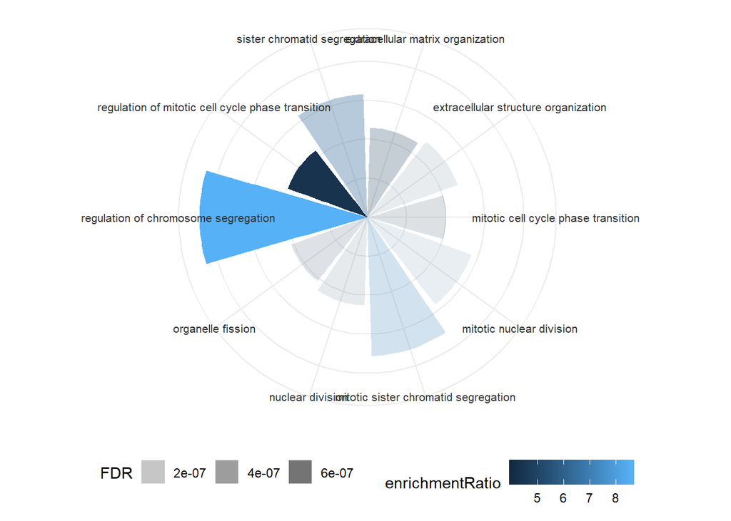

```r
enrichPlot(res = enrich$results,
           type = "circle")
```

#### Barplot

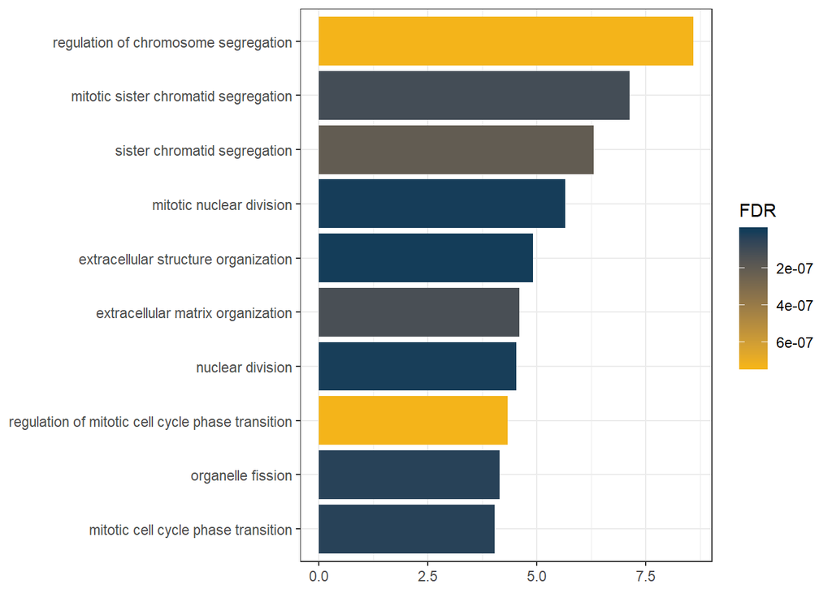

```r
enrichPlot(res = enrich$results,
           type = "bar")
```

#### Dotplot

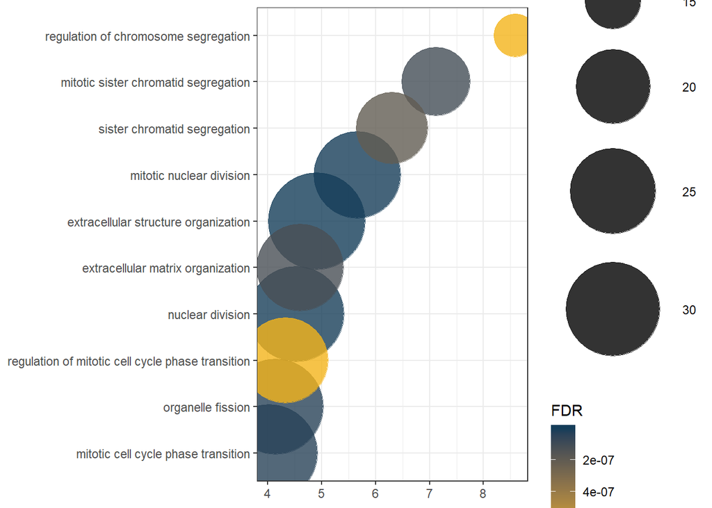

```r
enrichPlot(res = enrich$results,
           type = "dot")
```

## Network for Ontologies, genes and TFs

Generates the plot of groupGO or getEnrch network result of **getGroupGO** or **getEnrich** function, and the integrated network of genes, GOs and TFs.

#### Grouping by Pathways

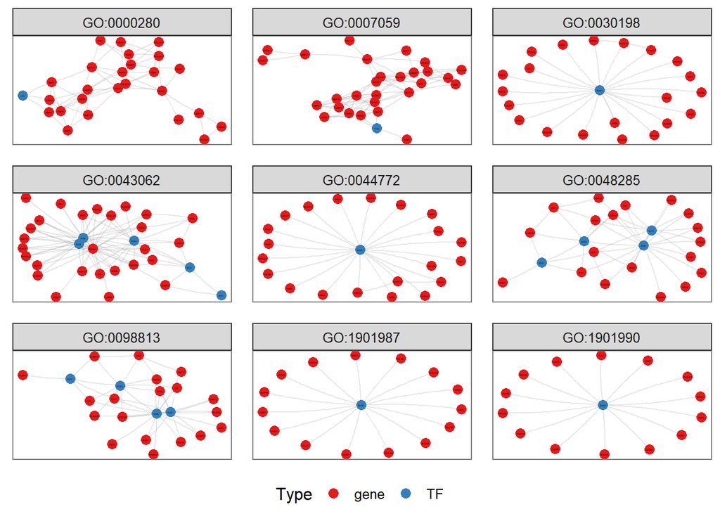

```r
t1 <- head(enrich$results, 15)
t2 <- subset(enrich$netGO, enrich$netGO$gene1 %in% as.character(t1[, "ID"]))
pt <- netGOTFPlot(netCond = NetworkData(out, "network1"),
                  resultsGO = t1,
                  netGO = t2,
                  anno = NetworkData(out, "annotation"),
                  groupBy = 'pathways',
                  type = 'GO')
pt$plot
```

#### Grouping by TFs

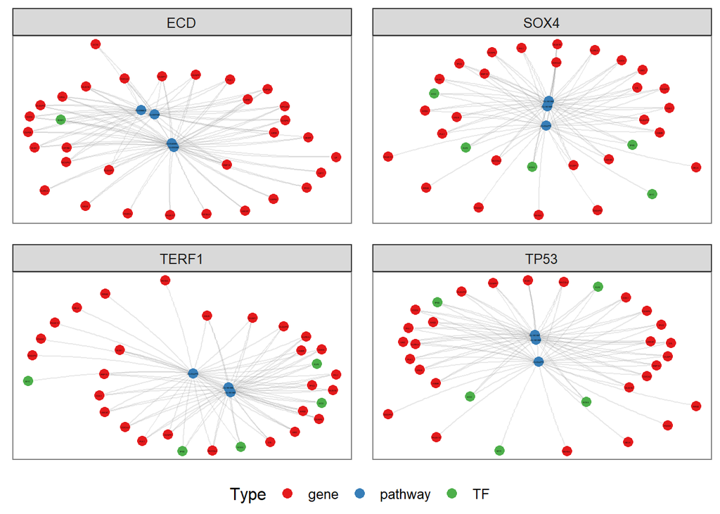

```r
TFs <- c("ECD", "SOX4", "TERF1", "TP53")
pt <- netGOTFPlot(netCond = NetworkData(out, "network1"),
                  resultsGO = t1,
                  netGO = t2,
                  anno = NetworkData(out, "annotation"),
                  groupBy = 'TFs',
                  TFs = TFs,
                  type = 'GO')
pt$plot
```

It is possible to choose for specif genes to visualize how them are related with the enriched pathways and TFs.

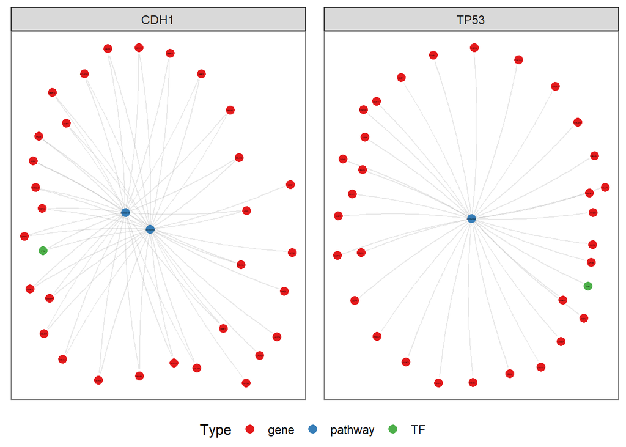

```r
genes <- c('CDH1', 'TP53')
pt <- netGOTFPlot(netCond = NetworkData(out, "network1"),
                  resultsGO = t1,
                  netGO = t2,
                  anno = NetworkData(out, "annotation"),
                  groupBy = 'genes',
                  genes = genes,
                  type = 'GO')
pt$plot
```

#### Integrated

It is also possible to integrate the TFs, genes and Pathways in the same network:

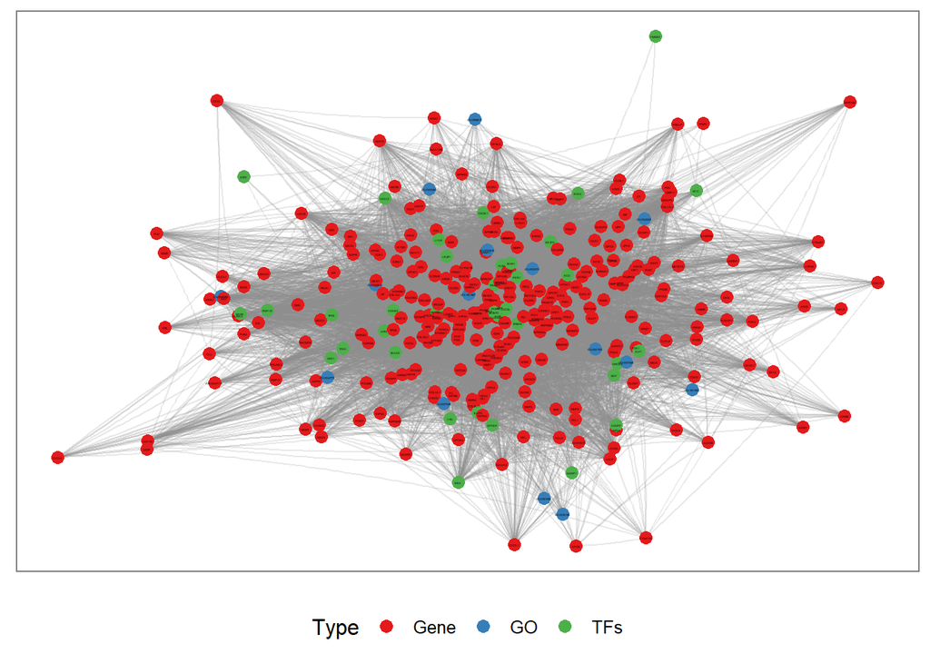

```r
pt <- netGOTFPlot(netCond = NetworkData(out, "network1"),
                  netGO = t2,
                  keyTFs = NetworkData(out, "keytfs"),
                  type = 'Integrated')
pt$plot
```

## Circos Targets

This plot makes it possible to visualize the targets of specific TFs or genes. The main idea is to identify which chromosomes are linked to the targets of a given gene or TF to infer whether there are cis (same chromosome) or trans (different chromosomes) links between them. The black links are between different chromosomes while the red links are between the same chromosome.

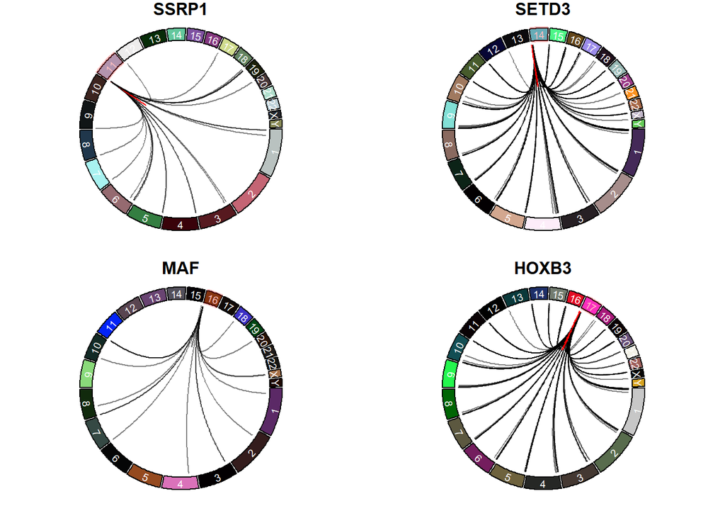

```r
CircosTargets(object = out,
              file = "C:/Users/carlo/Desktop/GTFs/Homo_sapiens.GRCh38.98.gtf",
              nomenclature = "SYMBOL",
              selection = c("SSRP1", "MAF", "SETD3", "HOXB3"),
              cond = "condition1")
```

## Diffusion Analysis

Network propagation is an important and widely used algorithm in systems biology, with applications in protein function prediction, disease gene prioritization, and patient stratification. Propagation provides a robust estimate of network distance between sets of nodes. Network propagation uses the network of interactions to find new genes that are most relevant to a set of well understood genes. To perform this analysis is necessary to install the latest Cytoscape software version and know the path that will be installed the software. After running the diffusion analysis is possible to perform the enrichment for the subnetwork resulted.

```r
result <- diffusion(object = out,
                    cond = "network1",
                    genes = "HOXB3",
                    cyPath = "C:/Program Files/Cytoscape_v3.7.2/Cytoscape.exe",
                    name = "top_diffusion",
                    label = T)
```

```
## Opening Cytoscape...
```

```
## Cytoscape opened!!
```

```
## Loading data...
## Applying default style...
## Applying preferred layout...
```

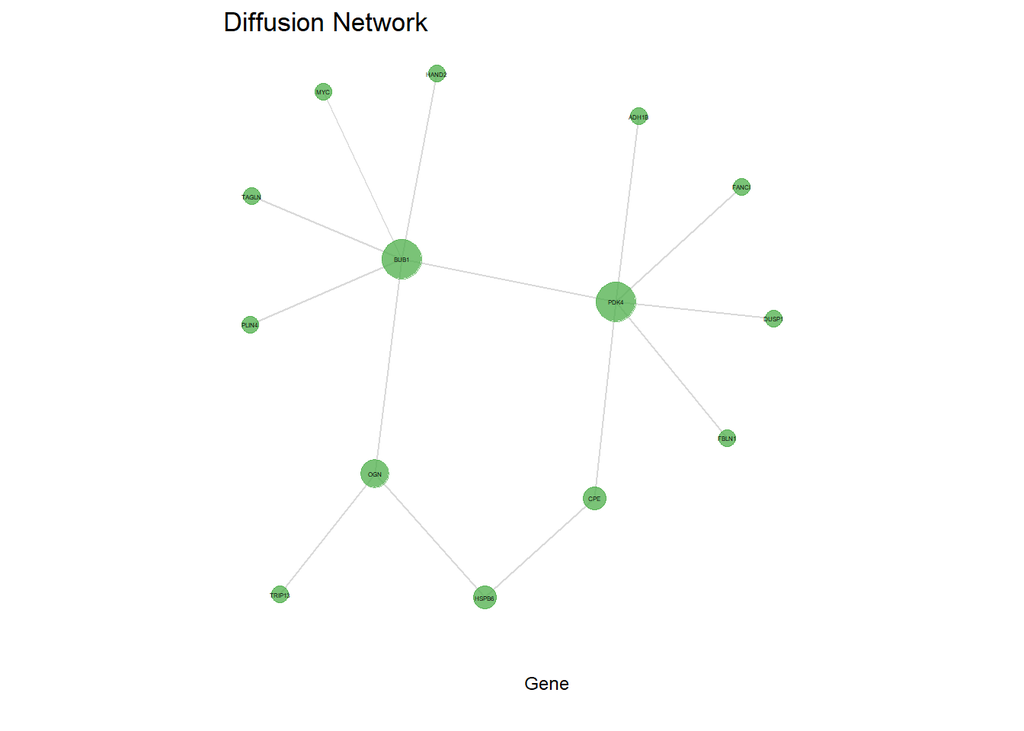

```r
result$plot
```